# ISLR - Chap2

GT

15 septembre 2016

## Chapter 2 - Statistical Learning

### What is statistical learning ?

The **`Advertising`** data set consist of the **`Sales`** of a product in 200 different markets along with advertising budgets for the product in each of those markets for three different media: **`TV`**, **`Radio`** and **`Newspaper`**.

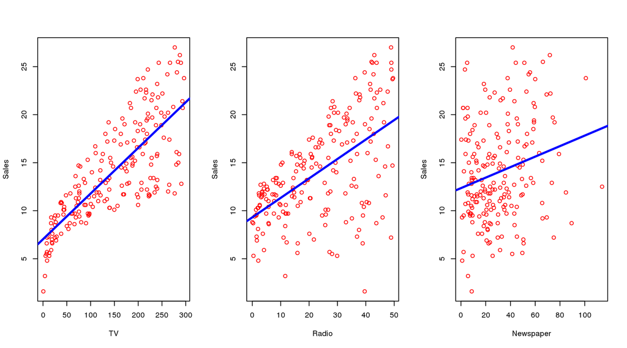

If we determine that there is an association between advertising and sales, then we can instruct our client to adjust advertising budgets, thereby indirectly increasing sales.

Our goal is to develop an accurate model that can be used to predict sales on the basis of the three media budgets.

The advertising budgets are *input variables* while **`Sales`** is an *output variable*. Input variable are typically denoted using the symbol $X$. $X_1$ might be the **`TV`** budget, $X_2$ the **`Radio`** budget, and $X_3$ the **`Newspaper`** budget. The ouput variable is typicall denoted using the symbol $Y$.

- The inputs are often called, *predictors*, *independent variables*, *features* or *variables*.
- The output variable is often called *response* or *dependent variable*

More generally, suppose that we observe a quantitative response $Y$ and $p$ different predictors, $X_1$,$X_2$,…,$X_p$. We assume that there is some relationship between $Y$ and $X=(X_1,X_2,…,X_p)$ which can be written in the very general form

$$Y=f(X)+\epsilon$$

$f$ is some fixed but unknown function of $X_1,…,X_p$, and $\epsilon$ is a random *error term*, which is independent of $X$ and has mean zero. $f$ represents the *systematic* information that $X$ provides about $Y$.

As another example, consider the plot of **`Income`** versus **`Years of education`** for 30 individuals in the **`Income`** data set. The plot suggests tthat one might be able to predict income using years of **`Education`**. However, the function $f$ that connects the input variable to the output variable is in general unkwnow. Since **`Income`** is a simulated data set, $f$ is known and is shown by the blue curve. The vertical lines represent the error terms $\epsilon$, overall, the errors have approximately mean zero.

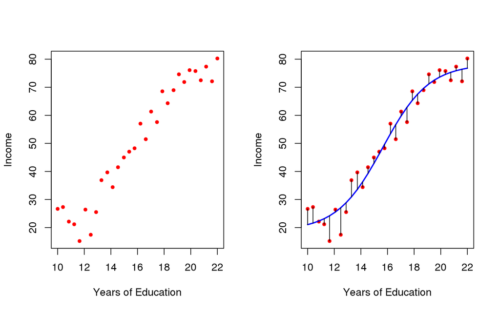

In essence, statistical learning refers to a set of approaches for estimating $f$.

#### Why Estimate $f$ ?

There are two main reasons that we may wish to estimate $f$: *prediction* and *inference*.

**Prediction**

In many situations, a set of inputs $X$ are readily available, but the output $Y$ cannot be easily obtained. In this setting, since the error term averages to zero, we can predict $Y$ using

$$\hat{Y}=\hat{f}(X)$$

where $\hat{f}$ represent our estimate for $f$, and $\hat{Y}$ represents the resulting prediction for $Y$. $\hat{f}$ is often treated as a *black box*, we’re not typically concerned with the exact form of $\hat{f}$, provided that it yields accurate predictions for $Y$.

The accuracy of $\hat{Y}$ as a prediction for $Y$ depends on two quantities, which we will call the *reducible error* and the *irreducible error*. In general, $\hat{f}$ will not be a perfect estimate for $f$, and this inaccuracy will introduce some error.

This error is *reducible* because we can potentially improve the accuracy of $\hat{f}$ by using the most appropriate statistical learning technique to estimate $f$. Howeve, even if it were possible to form a perfect estimate for $f$, $\hat{Y}=f(X)$, our prediction would still have some error in it! This is because $Y$ is also a function of $\epsilon$, which cannot be predict using $X$. This is known as the *irreducible error* because no matter how well we estimate $f$, we cannot reduce introduced by $\epsilon$.

**Inference**

We are often interested in urderstanding the way that $Y$ is affected as $X_1,…,X_p$ change. We wish to estimate $f$, but our goal is not necessarily to make predictions for $Y$. We want to understand how $Y$ changes as a function of $X_1,…,X_p$. Now $\hat{f}$ cannot be treated as a black box, because we need to know its exact form. One may be interested in answering the following questions:

- *Which predictors are associated with the response?* This is the case when only a small fraction of the available predictors are substantially associated with $Y$.
- *What is the relationship between the response and each predictor?* Some predictors may have a positive relationship with $Y$, in the sense that increasing the predictor is associated with increasing values of $Y$. Other predictors may have the opposite relationship.
- *Can the relationship between $Y$ and each predictor be adequately* *summarized using a linear equation, or is the relationship* *more complicated?* Often the true relationship is more complicated, in which case a linear model may not provide an accurate representation of the relationship between the input and output variables.

For instance, consider a company that is interested in conducting a direct-marketing campaign. The goal is to identify individuals who will respond positively to a mailing, based on observation of demographic variables measured on each individual. The company is not interested in obtaining a deep undestanding of the relationship between each individual predictor and the response; instead, the company simply wants an accurate model to predict the response using the predictors. This is an example of modelling for *prediction*.

In contrast, consider the **`Advertising`** data. One may be interested in answering questions such as:

- *Which media contribute to sales?*
- *Which media generate the biggest boost in sales?*
- *How much increase in sales is associated with a given increase* *in TV advertising?*

This situation falls into the *inference* paradigm.

Finally, some modelling could be conducted both for prediction and inference. For example, in a real estate setting, one may seek to relate values of homes to inputs such as crime rate, zoning, distance from a river, air quality, schools, income level of community, size of houses, and so forth. In this case one might be interested in how the individual input variables affect the prices, *how much extra will a house be worth if it has a view of the river?* This is an *inference problem*. Alternatively, one may simply be interested in predicting the value of a home given it’s characteristics: *is this house under- or over-valued?* This is a *prediction problem*.

*Linear models* allow for relatively simple and interpretable inference, but may not yield as accurate predictions as some other approaches. In contrast, some of the highly non-linear approaches can potetially provide quite accurate predictions for $Y$, but this comes at the expense of a less interpretable model for which inference is more challenging.

#### How Do We Estimate $f$?

We will assume that we have observed a set of $n$ different data points. These observations are called the *training data* because we will use these observations to train, or teach, our method how to estimate $f$.

Let $x_{ij}$ represent the value of the $j$ th predictor, or input, for observation $i$, where $i$ = 1,2,…,$n$ and $j$ = 1,2,…,$p$. Correspondingly, let $y_i$ represent the response variable for the $i$ th observation. Then our training data consist of ${(x_1,y_1),(x_2,y_2),…,(x_n,y_n)}$ where $x_i=(x_{i1},x_{i2},…,x_{ip})^T$.

Our goal is to apply a statistical learning method to the training data in order to estimate the unknown function $f$. In other words, we want to find a function such that $Y\approx\hat{f}(X)$ for any observation $(X,Y)$. Broadly speaking, most statistical learning methods for this task can be characterized as either *parametric* or *non-parametric*.

**Parametric Methods**

Parametric methods involve two-step model-based approach.

1. First, we make an assumption about the functional form, or shape, of $f$. For example, one very simple assumption is that $f$ is linear in $X$:

$$f(X)=\beta_0+\beta_1X_1+\beta_2X_2+…+\beta_pX_p$$

This is a *linear model*. Once we have assumed that $f$ is linear, the problem of estimating $f$ is greatly simplified. Instead of having to estimate an entirely arbitrary $p$-dimensional function $f(X)$, one only needs to estimate the $p+1$ coefficients $\beta_0$, $\beta_1$, …, $\beta_p$.

2. After a model has been selected, we need a procedure that uses the training data to *fit* or *train* the model. In the case of the linear model, we need to estimate the parameters $\beta_0$, $\beta_1$, …, $\beta_p$. That is, we want to find values of these parameters such that

$$Y\approx\beta_0+\beta_1X_1+\beta_2X_2+…+\beta_pX_p$$

The most common approach to fitting the model is referred to as *(ordinary) least squares*.

The model-based approach just described is referred to as *parametric*; it reduces the problem of estimating $f$ down to one of estimating a set of parameters. The potential disadvantage of a parametric approach is that the model we choose will usally not match the true unknown form of $f$. If the chosen model is too far from the true $f$, then our estimate will be poor.

We can try to address this problem by choosing *flexible* models that can fit many different possible functional forms for $f$. But in general, fitting a more flexible model requires estimating a greater number of parameters. These more complex models can lead to a phenomenon known as *overfitting* the data, which means they follow the errors, or *noise* too closely.

Figure shows an example of the parametric approach applied to the **`Income`** data. We have a linear model of the form

$$\textbf{income}\approx\beta_0+\beta_1\times\textbf{education}$$

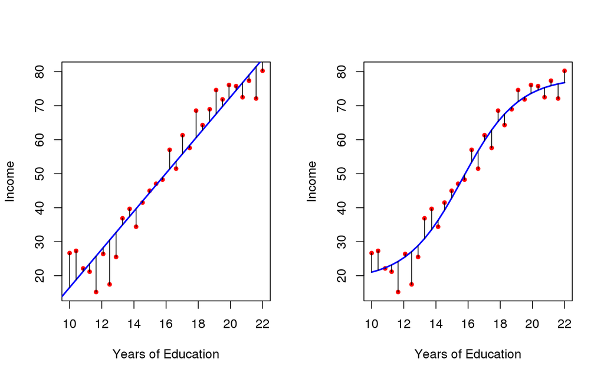

Since we have assumed a linear relationship between the response and the predictor, the entire fitting problem reduces to estimating $\beta_0$ and $\beta_1$, which we do using least squares linear regression. In the figure we can see that the linear fit is not quite right: the true $f$ has some curvature that is not captured in the linear fit. However, the linear fit still appears to do a reasonable job of capturing the positive relationship between **`years of education`** and **`income`**. It may be that with such a small number of observations, this is the best we can do.

**Non-parametric Methods**

Non-parametric methods do not make explicit assumptions about the functional form of $f$. Instead they seek an estimate of $f$ that gets as close to the data points as possible without being too rough or wiggly. Such approaches can have a major advantage over parametric approaches: by avoiding the assumption of a particular functional form for $f$, they have the potential to accurately fit a wider range of possible shapes for $f$. But non-parametric approaches do suffer from a major disadvantage: since they do not reduce the problem of estimating $f$ to a small number of parameters, a very large number of observations is required in order to obtain an accurate estimate for $f$.

#### The Trade-Off Between Prediction Accuracy and Model Interpretability

Of the many methods, some are less flexible, or more restrictive, in the sense that they can produce just a relatively small range of shapes to estimate $f$. For example, linear regression is a relatively inflexible approach, because it can only generate linear functions.

One might reasonably ask the following question: *why would we* *ever choose to use a more restrictive method instead of a* *very flexible approach?* If we are mainly interested in inference, then restrictive models are much more interpretable.

For instance, when inference is the goal, there are clear advantages to using simple and relatively inflexible statistical learning methods, as the linear model. This may be a good choice since it will be quite easy to understand the relationship between $Y$ and $X_1,X_2,…,X_p$. In contrast, very flexible approaches, such as the splines, can lead to such complicated estimates of $f$ that it is difficult to understand how any individual predictor is associated with the response.

In some settings, however, we are only interested in prediction, and the interpretability of the predictive model is simply not of interest. For instance, if we seek to develop an algorithm to predict the price of a stock, our sole requirement for the algorithm is that it predict accurately. In this setting, we might expect thate it will be best to use the most flexible model available.

Surprisingly, this is not always the case!

We will often obtain more accurate predictions using a less flexible method. This phenomenon, which may seem counterintuitive at first glance, has to do with the potential for overfitting in highly flexible methods.

#### Supervised Versus Unsupervised Learning

Most statistical learning problems fall into one of two categories: *supervised* or *unsupervised*. For each observation of the predictor measurement $x_i$, $i$=1,…,$n$ there is an associated response measurement $y_i$. We wish to fit a model that relates the response to the predictors, with the aim of accurately predicting the response for future observations (prediction) or better undertstanding the relationship between the response and the predictors (inference). Many classical statistical learning methods such as linear regression and logistic regression operate in the supervised learning domain.

In contrast, unsupervised learning describes the somewhat more challenging situation in which for every observation $i$=1,…,$n$, we observe a vector of measurement $x_i$ but no associated response $y_i$. It is not possible to fit a linear regression model, since there is no response variable to predict. In this setting, we are in some sense working blind; the situation is referred to as *unsupervised* because we lack a response variable that can supervise our analysis.

What sort of statistical analysis is possible ?

We can seek to understand the relationship between the variables or between the observations. One statistical learning tool that we may use in this setting is *cluster analysis*, or clustering. The goal of cluster analysis is to ascertain, on the basis of $x_1,…,x_n$, whether the observations fall into relatively distinct groups. For example, in market segmentation study we might observe multiple characteristics for potential customers, such a zip code, family income, and shopping habits. We might believe that the customers fall into different groups, such as big spenders versus low spenders. If the information about each customer’s spending patterns were available, then a supervised analysis would be possible. However, this information is not available. In this setting, we can try to cluster the customers on the basis of the variables measured, in order to identify distinct groups of potential customers. Identify such groups can be of interest because it might be that the groups differ with respect to some property of interest, such as spending habits.

#### Regression Versus Classification Problems

Variables can be characterized as either *quantitative* or *qualitative*. Quantitative variables take on numerical values. Examples include a person’s age, height, or income. In contrast, qualitative variables take on values on onk of $K$ different *classes*, or categories. Examples include a person’s gender (male or female), the brand of product purchased (brand A, B or C), or a cancer diagnosis (Acute Myelogenous Leukemia, Acute Lymphoblastic Leukemia, or No Leukemia).

We tend to refer to problems with a quantitative response as *regression* problems, while those involving a qualitative response are often referred to as *classification* problems. However, the distinction is not always that crisp. Least squares linear regression is used with a quantitative response, whereas logistic regression is typically used with a qualitative response. As such it is often used as a classification method. But since it estimates class probabilities, it can be thought of as a regression method as well.

We tend to select statistical learning methods on the basis of whether the response is quantitative or qualitative. However, whether the *predictors* are qualitative or quantitative is generally considered less important.

### Assessing Model Accuracy

Selecting the best approach can be one of the most challenging parts of performing statistical learning in practice.

#### Measuring the Quality of Fit

In order to evaluate the performance of a statistical learning method on a given data set, we need some way to measure how well its predictions actually match the observed data. In the regression setting, the most commonly-used measure is the *mean squared error* (MSE), given by

$$MSE=\frac{1}{n}\sum_{i=1}^{n}(y_i-\hat{f}(x_i))^2$$

where $\hat{f}(x_i)$ is the prediction that $\hat{f}$ gives for the $i$ th observation. The MSE will be small if the predicted response are very close to the true responses, and will be large if for some of the observations, the predicted and true responses differ substantially.

To state it more mathematically, suppose that we fit our statistical learning method on our training observations ${(x_1,y_1),(x_2,y_2),…,(x_n,y_n)}$, and we obtain the estimate $\hat{f}$. We can then compute $\hat{f}(x_1),\hat{f}(x_2),…,\hat{f}(x_n)$. If these are approximately equal to $y_1,y_2,…,y_n$, then the training MSE is small. However, we are really not interested in wheter $\hat{f}(x_i)\approx(y_i)$; instead, we want to know whether $\hat{f}(x_0)$ is approximately equal to $y_0$, where $(x_0,y_0)$ is a *previously unseen test observation not used to train the statistical* *learning method*. We want to choose the method that gives the lowest *test MSE*, as opposed to the lowest training MSE. In other words, if we had a large number of test observations, we could compute

$$Ave(y_0-\hat{f}(x_0))^2$$

the average squared prediction error for these test observations $(x_0,y_0)$.

How can we go about trying to select a method that minimizes the test MSE? In some settings, we may have a test data set available and we can simply evaluate on the test observations, and select the learning method for which the test MSE is smallest. But what if no test observations are available? In that case, one might imagine simply selecting a statistical learning method that minimizes the training MSE. This seems like it might be a sensible approach, since the training MSE and the test MSE appear to be closely related. Unfortunately, there is a fundamental problem with this strategy: there is no guarantee that the method with the lowest training MSE will also have the lowest test MSE. The problem is that many statistical methods specifically estimate coefficients so as to minimize the training set MSE. For these methods, the training set MSE can be quite small, but the test MSE is often much larger.

A fundamental property of statistical learning hold regardless of the particular data set at hand and regardless of the statistical method being used. As model flexibility increases, training MSE will decrease, but the test MSE may not. When a given method yields a small training MSE but a large test MSE, we are said to be *overfitting* the data. This happens because our statistical learning procedure is working too hard to find patterns that are just caused by random chance rather than by true properties of the unknown function $f$. Overfitting refers specifically to the case in which a less flexible model would have yielded a smaller test MSE.

#### The Bias-Variance Trade-Off

It is possible to show that the expected test MSE, for a given value $x_0$, can always be decomposed into the sum of three fundamental quantities: the *variance* of $\hat{f}(x_0)$, the squared *bias* of $\hat{f}(x_0)$ and the variance of the error terms $\epsilon$. That is,

$$E(y_0-\hat{f}(x_0))^2=Var(\hat{f}(x_0))+[Bias(\hat{f}(x_0))]^2+Var(\epsilon)$$

Here the notation $E(y_0-\hat{f}(x_0))^2$ defines the *expected test MSE*, and refers to the average test MSE that we would obtain if we repeatedly estimated $f$ using a large number of training sets, and tested each at $x_0$. The overall expected test MSE can be computed by averaging $E(y_0-\hat{f}(x_0))^2$ over all possible values of $x_0$ in the test set. In order to minimize the expected test error, we need to select a statistical learning method that simultaneously achieves *low variance* and *low bias*. Note that the variance is inherently a nonegative quantity, and squared bias is also nonnegative. Hence, we see that the expected test MSE can never lie below $Var(\epsilon)$, the irreducible error.

What do we mean by the *variance* and *bias* of a statistical learning method ?

*Variance* refers to the amount by which $\hat{f}$ would change if we estimated it using a different training data set. Since the training data are used to fit the statistical learning method, different training data sets will result in a different $\hat{f}$. But ideally the estimate for $f$ should not vary too much between training sets. In general, more flexible statistical methods have higher variance, then small changes in the training data can result in large changes in $\hat{f}$. In contrast, relative inflexible method has low variance, because moving any single observation will likely cause only a small shift in the estimate $\hat{f}$.

*Bias* refers to the error that is introduced by approximating a real-life problem, which may be extremely complicated, by a much simpler model. For example, linear regression assumes that there is a linear relationship between $Y$ and $X_1,X_2,…,X_p$. It is unlikely that any real-life problem truly has such a simple linear relationship, and so performing linear regression will undoubtedly result in some bias in the estimate of $f$. If the relationship is non-linear, no matter how many training observations we are given, it will not be possible to produce an accurate estimate using linear regression, this results in high bias. However, the the true $f$ is very close to linear, and so given enough data, it should be possible for linear regression to produce an accurate estimate. Generally, more flexible methods result in less bias.

As a general rule, as we use more flexible methods, the variance will increase and the bias will decrease. The relative rate of change of these two quantities determines wheter the test MSE increases or decreases. As we increase the flexibility of a class of methods, the bias tends to initially decrease faster than the variance increases. Consequently, the expected test MSE declines. However, at some point increasing flexibility has little impact on the bias but starts to significantly increase the variance. When this happens the test MSE increase.

The relationship between bias, variance, and test set MSE is referred to as the *bias-variance trade-off*. This is because it is easy to obtain a method with extremely low bias but high variance or a method with very low variance but high bias. The challenge lies in finding a method for which both the variance and the squared bias are low. In a real-life situation in which $f$ is unobserved, it is generally not possible to explicity compute the test MSE, bias or viariance for a statistical learning method. Nevertheless, one should always keep the bias-variance trade-off in mind.

#### The Classification Setting

Many of the concepts that we have encountered, such as the bias-variance trade-off, transfer over to the classification setting with only some modifications due to the fact that $y_i$ is no longer numerical. Suppose that we seek to estimat $f$ on the basis of training observations ${(x_1,y_1),…,(x_n,y_n)}$, where now $y_1,…,y_n$ are qualitative. The most common approach for quantifying the accuracy of our estimate $\hat{f}$ is the training *error rate*, the proportion of mistakes that are made if we apply our estimate $\hat{f}$ to the training observations:

$$\frac{1}{n}\sum_{i=1}^{n}I(y_i\neq\hat{y}_i)$$

Here $\hat{y}_i$ is the predicted class label for the $i$ th observation using $\hat{f}$. And $I(y_i\neq\hat{y}_i)$ is an *indicator variable* that equals 1 if $y_i\neq\hat{y}_i$ and zero if $y_i=\hat{y}_i$. If $I(y_i\neq\hat{y}_i)=0$ then the $i$ th observation was classified correctly by our classification method; otherwisi it was misclassified. Hence computes the fraction of incorrect classifications. The equation is referred to as the *training error* rate because it is computed based on the data that was used to train our classifier. As in the regression setting, we are most interested in the error rates that result from applying our classifier to test observations that were not used in training. The *test error* rate associated with a set of test observations of the form $(x_0,y_0)$ is given by

$$Ave(I(y_0\neq\hat{y}_0))$$

where $\hat{y}_0$ is the predicted class label that results from applying the classifier to the test observation with predictor $x_0$. A *good* classifier is one for which the test error is smallest.

**The Bayes Classifier**

It is possible to show that the test error rate is minimized, on average, by a very simple classifier that *assigns each observation* *to the most likely class, given its predictor values*. In other words, we should simply assign a test observation with predictor vector $x_0$ to the class $j$ for which

$$Pr(Y=j|X=x_0)$$

is largest. This is a *conditional probability*: it is the probability that $Y=j$, given the observed predictor vector $x_0$. This very simple classifier is called the *Bayes classifier*. In a two-class problem where there are only two possible response values, ‘class1’ or ‘class2’, the Bayes classfier corresponds to predict class one if $Pr(Y=1|X=x_0)>0.5$, and class two otherwise.

The Bayes classifier produces the lowest possible test error rate, called the *Bayes error rate*. Since the Bayes classifier will always choose the class for which $Pr(Y=j|X=x_0)$ is largest, the error rate at $Y=x_0$ will be $1-max_jPr(Y=j|X=x_0)$. In general, the overall Bayes error rate is given by

$$1-E(max_jPr(Y=j|X))$$

where the expectation averages the probability over all possible values of X. The Bayes error rate is analogous to the irreducible error.

**K-Nearest Neighbors**

In theory we would always like to predict qualitative responses using the Bayes classifier. But for real data, we do not know the conditional distribution of $Y$ given $X$, and so computing the Bayes classifier is impossible. Therefore, the Bayes classifier serves as an unattainable gold standard against which to compare other methods. Many approachs attempt to estimate the conditional distribution of $Y$ given $X$, and then classify a given observation to the class with highest *estimated* probability. One such method is the *K-nearest neighbors* (KNN) classifier. Given a positive integer $K$ and a test observation $x_0$, the KNN classifier first identifies the $K$ points in the training data that are closest to $x_0$, represented by $N_0$. It then estimate the conditional probability for class $j$ as the fraction of points in $N_0$ whose response values equal $j$:

$$Pr(Y=j|X=x_0)=\frac{1}{K}\sum_{i\in N_0}I(y_i=j)$$

Finally, KNN applies Bayes rule and classifies the test observation $x_0$ to che class with the largest probability.

Despite the fact that it is a very simple approach, KNN can often produce classifiers that are surprisingly close to the optimal Bayes classifier. The choice of $K$ has a drastic effect on the KNN classifier obtained. When $K=1$, the decision boundary is overly flexible and finds patterns in the data that don’t correspond to the Bayes decision boundary. This corresponds to a classifier that has low bias but very high variance. As $K$ grows , the methods becomes less flexible and produces a decision boundary that is close to linear. This corresponds to a low-variance but high-bias classifier.

Just as in the regression setting, there is not a strong relationship between the training error rate and the test error rate. With $K=1$, the KNN training error rate is 0, but the test error rate may be quite high. In general, as we use more flexible classification methods, the training error rate will decline but the test error rate may not.

In both the regression and classification settings, choosing the correct level of flexibility is critical to the succes of any statistical learning method.

### Lab: Introduction to R

The best way to learn a new language is to try out the commands.

#### Loading Data

Load the `Auto` data set. This data set is part of the `ISLR` library.

```r
library(ISLR)
```

```r
dim(Auto)
```

```
## [1] 392   9
```

```r
# Check the variables names
names(Auto)
```

```
## [1] "mpg"          "cylinders"    "displacement" "horsepower"
## [5] "weight"       "acceleration" "year"         "origin"
## [9] "name"
```

#### Graphical and Numerical Summaries

We can use the `plot()` function to produce *scatterplots* of quantitative variables.

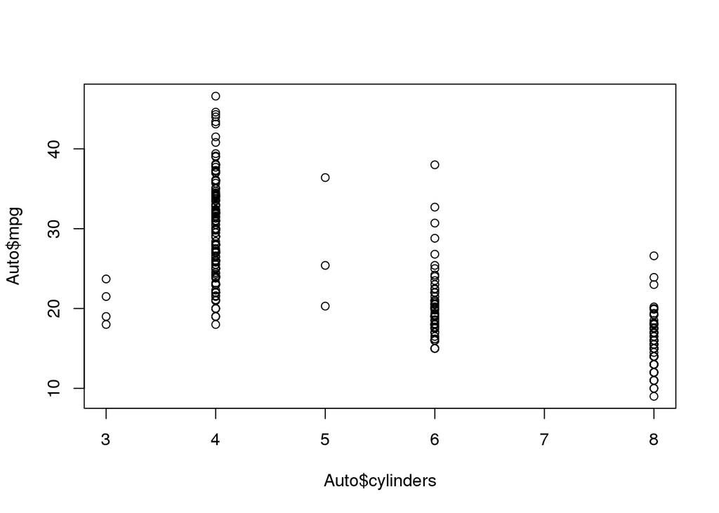

```r
plot(Auto$cylinders, Auto$mpg)
```

The `cylinders` variable is stored as a numeric vector, so *`R`* has treated it as quantitative. However, since there are only a small number possible values for cylinders, one may prefer to treat it as a qualitative variable.

```r
# The as.factor() function converts quantitative variable into
# qualitative variable
Auto$cylinders = as.factor(Auto$cylinders)
```

If the variable plotted on the x-axis is categorical, then *boxplots* will be automatically be produced by the `plot()` function.

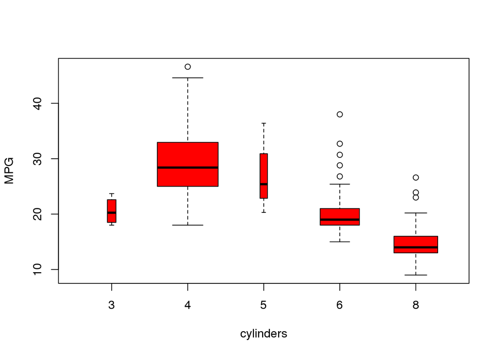

```r
plot(Auto$cylinders, Auto$mpg, col="red", varwidth=T,
     xlab="cylinders",
     ylab="MPG")
```

The `hist()` function can be used to plot a *histogram*.

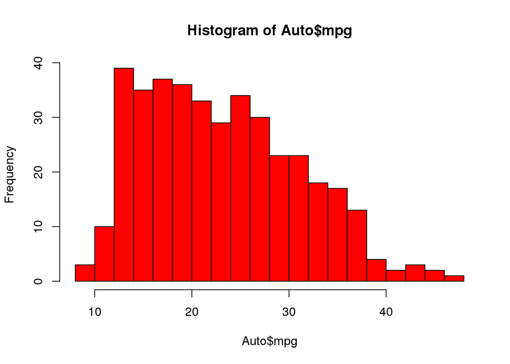

```r
hist(Auto$mpg, col=2, breaks=15)
```

The `pairs() function creates a *scatterplot matrix*.

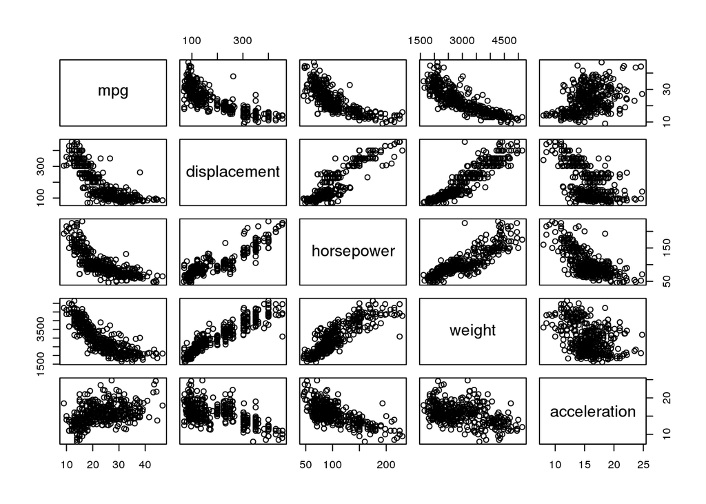

```r
pairs(~ mpg + displacement + horsepower + weight + acceleration, Auto)
```

The `summary()` function produces a numerical summary of each variable in a particular data set

```r
summary(Auto)
```

```
##       mpg        cylinders  displacement     horsepower        weight
##  Min.   : 9.00   3:  4     Min.   : 68.0   Min.   : 46.0   Min.   :1613
##  1st Qu.:17.00   4:199     1st Qu.:105.0   1st Qu.: 75.0   1st Qu.:2225
##  Median :22.75   5:  3     Median :151.0   Median : 93.5   Median :2804
##  Mean   :23.45   6: 83     Mean   :194.4   Mean   :104.5   Mean   :2978
##  3rd Qu.:29.00   8:103     3rd Qu.:275.8   3rd Qu.:126.0   3rd Qu.:3615
##  Max.   :46.60             Max.   :455.0   Max.   :230.0   Max.   :5140
##
##   acceleration        year           origin                      name
##  Min.   : 8.00   Min.   :70.00   Min.   :1.000   amc matador       :  5
##  1st Qu.:13.78   1st Qu.:73.00   1st Qu.:1.000   ford pinto        :  5
##  Median :15.50   Median :76.00   Median :1.000   toyota corolla    :  5
##  Mean   :15.54   Mean   :75.98   Mean   :1.577   amc gremlin       :  4
##  3rd Qu.:17.02   3rd Qu.:79.00   3rd Qu.:2.000   amc hornet        :  4
##  Max.   :24.80   Max.   :82.00   Max.   :3.000   chevrolet chevette:  4
##                                                  (Other)           :365
```